### Exploring age mixing

First we prepare the data and define age difference variables

```r
#Select ego and alter age variables
age_explore <- sample %>% filter(!is.na(mrp_ageinyears_approx)) %>% select(age, mrp_ageinyears_approx)
#Define a variable to indicate the older of the two partners' ages
age_explore$olderpartner <- apply(age_explore, 1, max)

#Define age differences
age_explore$agediff <- abs(age_explore$age - age_explore$mrp_ageinyears_approx)
age_explore$sqrt_agediff <- abs(sqrt(age_explore$age) - sqrt(age_explore$mrp_ageinyears_approx))
age_explore$cbrt_agediff <- abs(age_explore$age^(1/3) - age_explore$mrp_ageinyears_approx^(1/3))

#Define a variable to highlight specific age differences on the plot
age_explore$flagdiffs <- ifelse(age_explore$agediff %in% 6, "6 year diff", ifelse(age_explore$agediff %in% 15, "15 year diff", "other diff"))
```

List the first 20 rows to check that the variables were defined appropriately

```r
age_explore[1:20,] %>% select(age, mrp_ageinyears_approx, agediff, sqrt_agediff, cbrt_agediff)
```

```
##    age mrp_ageinyears_approx agediff sqrt_agediff cbrt_agediff
## 1   51                    50       1   0.07036062   0.02439827
## 2   35                    24      11   1.01710030   0.38656717
## 3   49                    50       1   0.07106781   0.02472579
## 4   43                    29      14   1.17227372   0.43108123
## 5   56                    50       6   0.41224696   0.14183087
## 6   46                    47       1   0.07332462   0.02577821
## 7   50                    27      23   1.87491539   0.68403150
## 8   50                    43       7   0.51362929   0.18063344
## 9   46                    43       3   0.22489146   0.07964981
## 10  29                    19      10   1.02626586   0.40391518
## 11  31                    36       5   0.43223564   0.16054660
## 12  20                    35      15   1.44394383   0.55664869
## 13  19                    21       2   0.22367675   0.09052253
## 14  46                    26      20   1.68331047   0.62055180
## 15  57                    59       2   0.13131131   0.04449528
## 16  57                    50       7   0.47876662   0.16446963
## 17  42                    45       3   0.22746323   0.08086666
## 18  22                    47      25   2.16523884   0.80678675
## 19  22                    22       0   0.00000000   0.00000000
## 20  28                    40      12   1.03305270   0.38336292
```

For the first 50 observations, plot the absolute value of the difference between the partners’ ages in years, the absolute value of the difference between the square root of the partners’ ages, and the absolute value of the difference between the cube root of the partners’ ages on the same plot. The x-axis is the older of the two partner’s ages.

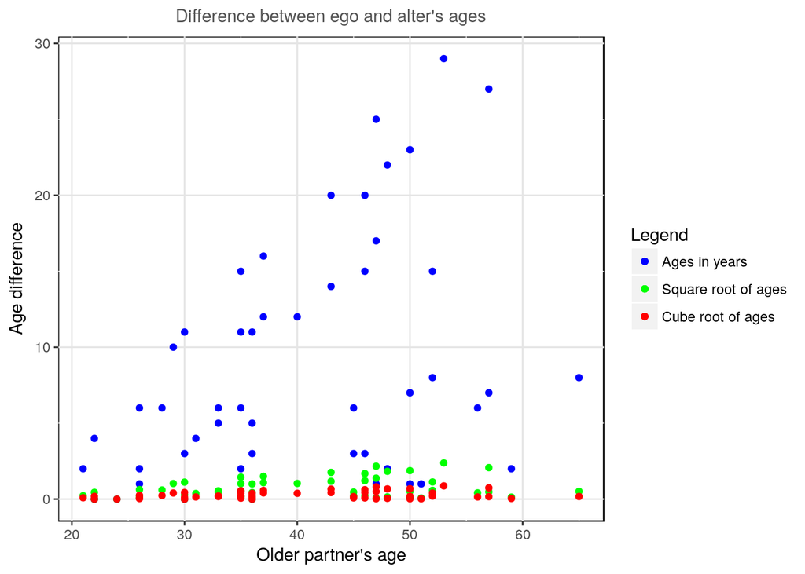

```r
ggplot(age_explore[1:50,]) + geom_point(aes(x=olderpartner, y=agediff, color="a")) + geom_point(aes(x=olderpartner, y=sqrt_agediff, color="b")) + geom_point(aes(x=olderpartner, y=cbrt_agediff, color="c")) + scale_colour_manual(name = "Legend", values=c("a"="blue", "b"="green", "c"="red"), labels=c("Ages in years", "Square root of ages", "Cube root of ages")) + theme_title + plot_background + labs(x="Older partner's age", y="Age difference", title="Difference between ego and alter's ages")
```

Plot each difference separately. In these plots, 6- and 15-year age differences are highlighted to make it easier to track how taking the square and cube root of ages changes the relative position of points with the same absolute difference in age.

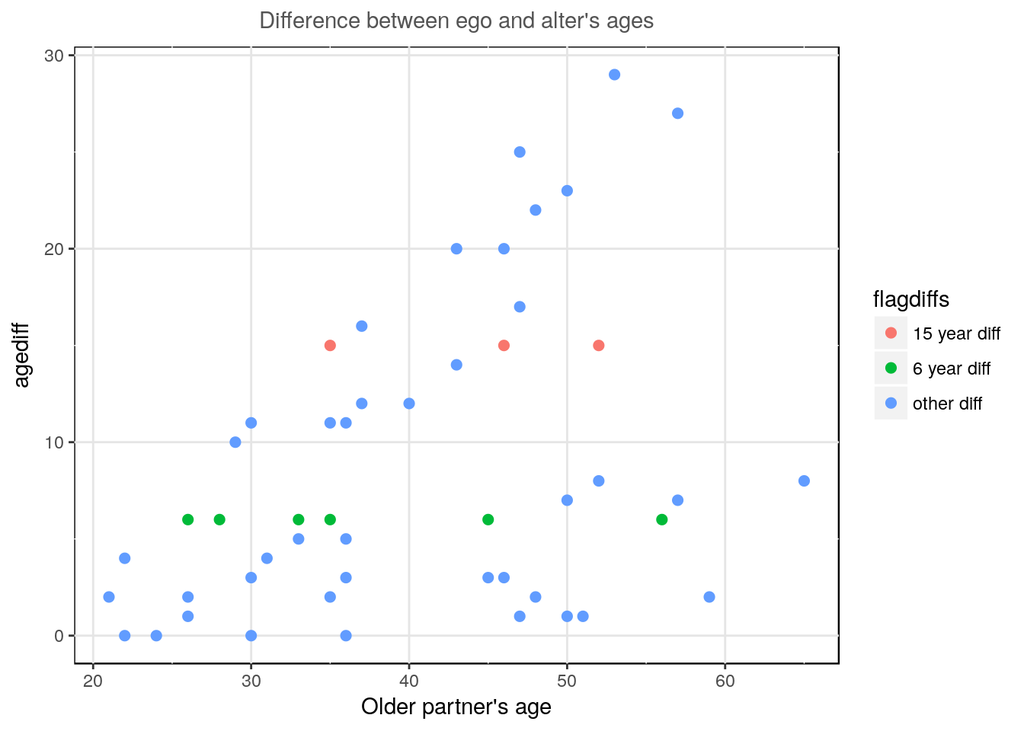

```r
p_ages <- ggplot(age_explore[1:50,]) + geom_point(aes(x=olderpartner, y=agediff, colour=flagdiffs), size=2) + theme_title + plot_background + labs(x="Older partner's age", title="Difference between ego and alter's ages")

p_sqrt <- ggplot(age_explore[1:50,]) + geom_point(aes(x=olderpartner, y=sqrt_agediff, colour=flagdiffs), size=2) + theme_title + plot_background + labs(x="Older partner's age", title="Difference between square root of ego and alter's ages")

p_cbrt <- ggplot(age_explore[1:50,]) + geom_point(aes(x=olderpartner, y=cbrt_agediff, colour=flagdiffs), size=2) + theme_title + plot_background + labs(x="Older partner's age", title="Difference between cube root of ego and alter's ages")

p_ages
```

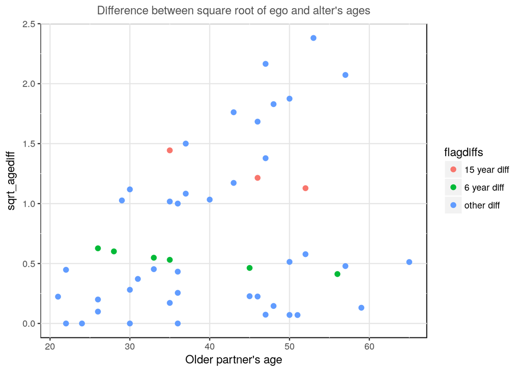

```r
p_sqrt
```

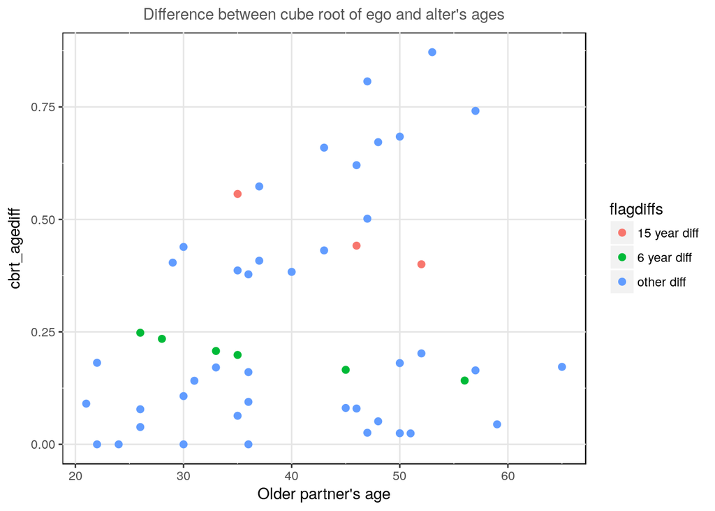

```r
p_cbrt
```

**Interpretation**: It looks like taking the square root and cube root of ego and alter ages does make the magnitude of the same difference in age smaller if the partners involved in the dyad are older. But the trend across ages appears the same in all three plots… The plots below use data from the full sample (not just the first 50 observations) and stratify by partner type.

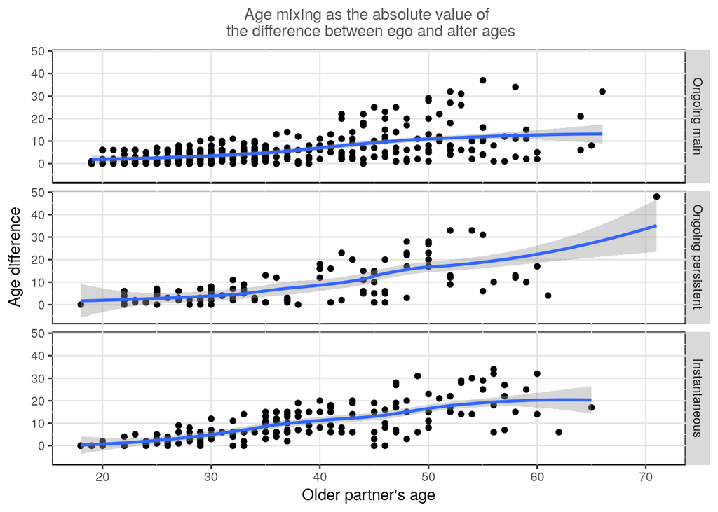

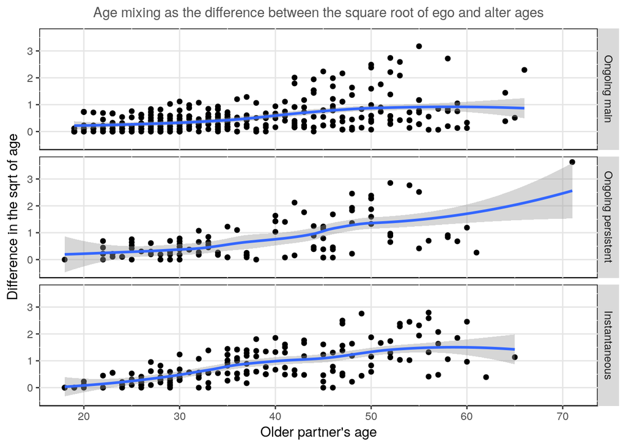

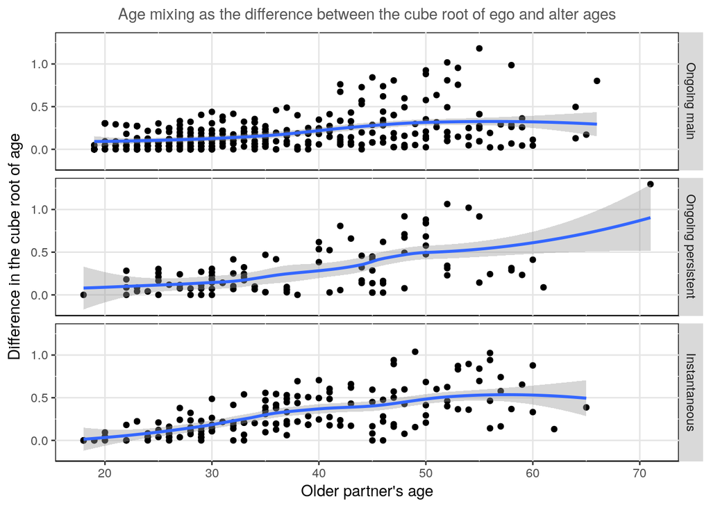